# Top Brands YouTube Chanel Statistics

## 1 SAMSUNG

Samsung is a big name in phone companies and has emerged as one of the top mobile brands in the world. It is a South Korean company founded on 1st March 1938. It is one of the most trusted brands in the world because of the top-notch facilities provided by the company and its long-lasting smartphones. The smartphones sold by this company are very much user-friendly, the best innovative software, proper customer care facility, cost-effective, etc.

## 2 APPLE

It is one of the most premium mobile brands in the world. It is an American multinational technology company and is one of the biggest tech companies in the world. It was founded on April 1st, 1976 by Steve Jobs, Steve Wozniak, Ronald Wayne. The top smartphone hand of this company includes Apple iPhone 11, iPhone 11 Pro, iPhone X, iPhone XS Max, iPhone XR, iPhone 8, iPhone 8 Plus, iPhone SE.

## 3 HUAWEI

It’s one of the wide-ranging smartphone brands in the world. It is a Chinese multinational company founded in 1987 by Ren Zhengfei. Popular handsets launched by this company are Huawei P30 Pro, Huawei Mate 20 Pro, Huawei P30, etc.

## 4 XIAOMI

It is a Chinese multinational company founded in April 2010 by Lei Jun. With just a few years of its release, it has given a tough competition to its competitors. It’s the world’s 4th most valuable technology startup. Popular smartphones released by this company are Mi 10 Ultra, Redmi Note 9 Pro, Redmi Note 9, Redmi 9, Redmi Note 8, Poco F2 Pro, and Redmi Note 8 pro.

## 5 OPPO

Guangdong OPPO Mobile Telecommunication Corp., Ltd, stylized as OPPO, is a Chinese company founded by Tony Chen in 2001. Some popular handset launched by the company is OPPO A31, OPPO F15, OPPO A5, OPPO F9, OPPO A9, OPPO Reno2, OPPO F3, F5, F7, F11 Pro, F5 Youth, OPPO A83.

## 6 VIVO

VIVO Communication Technology Co. Ltd. Is a Chinese tech company founded in 2009 by Shen Wei. Vivo offers a wide range of phones with great features and specifications. Popular smartphones launched by the company are Vivo V17 Pro, VIVO Z1x, VIVO S1 Pro, VIVO S1, VIVO V17, VIVOZ1 Pro, VIVO S1, VIVO U20, VIVO U10, VIVO V15, VIVO Y11.

## 7 MOTOROLA

It’s an American multinational telecommunications company in 1928 founded by Paul and Joseph Galvin. After facing a loss of $4.3 billion from 2007 to 2009. The company got divided into two independent public companies, Motorola Mobility and Motorola Solutions in 2011. Popular mobiles launched by this company are Motorola Razr, Mate X, MOTO G8 Plus, MOTO Z4, Motorola One Action, MOTO Z3, MOTO G7 Power, MOTO G7 Plus and Motorola One Vision.

```python
# lets import libraries
from googleapiclient.discovery import build
import pandas as pd
import seaborn as sn
```

## 1 SAMSUNG

```python
# Function to get channel statistics
api_key = 'AIzaSyB24Kop04L1GlTgRCm1XtQ4KB2a4gaBOwA'
SAMSUNG_channel_id = ['UCWwgaK7x0_FR1goeSRazfsQ' # SAMSUNG

              ]
youtube = build('youtube','v3',developerKey = api_key)

from googleapiclient.errors import HttpError

def get_channel_stats(youtube, SAMSUNG_channel_id):
    all_data = []
    try:
        request = youtube.channels().list(
            part='snippet,contentDetails,statistics',
            id=','.join(SAMSUNG_channel_id)
        )
        response = request.execute()

        for item in response.get('items', []):
            snippet = item.get('snippet', {})
            statistics = item.get('statistics', {})

            data = {
                'Channel_name': snippet.get('title', ''),
                'Subscribers': statistics.get('subscriberCount', ''),
                'Views': statistics.get('viewCount', ''),
                'Total_videos': statistics.get('videoCount', '')
            }

            all_data.append(data)

    except HttpError as e:
        print(f"HTTP error occurred: {e}")
        print(f"Request URL: {e.resp.request.url}")
        print(f"Request body: {e.resp.request.body}")

    return all_data
```

```python
get_channel_stats(youtube,SAMSUNG_channel_id)
```

```
[{'Channel_name': 'Samsung',
  'Subscribers': '6710000',
  'Views': '1811453473',
  'Total_videos': '2129'}]
```

```python
channel_statistics = get_channel_stats(youtube, SAMSUNG_channel_id)
```

```python
SAMSUNG_channel_data =pd.DataFrame(channel_statistics)
```

```python
SAMSUNG_channel_data
```

|  | Channel_name | Subscribers | Views | Total_videos |
| --- | --- | --- | --- | --- |
| 0 | Samsung | 6710000 | 1811453473 | 2129 |

## 2 APPLE

```python
# Function to get channel statistics
api_key = 'AIzaSyB24Kop04L1GlTgRCm1XtQ4KB2a4gaBOwA'
APPLE_channel_id = ['UCE_M8A5yxnLfW0KghEeajjw' # APPLE

              ]
youtube = build('youtube','v3',developerKey = api_key)

from googleapiclient.errors import HttpError

def get_channel_stats(youtube, APPLE_channel_id):
    all_data = []
    try:
        request = youtube.channels().list(
            part='snippet,contentDetails,statistics',
            id=','.join(APPLE_channel_id )
        )
        response = request.execute()

        for item in response.get('items', []):
            snippet = item.get('snippet', {})
            statistics = item.get('statistics', {})

            data = {
                'Channel_name': snippet.get('title', ''),
                'Subscribers': statistics.get('subscriberCount', ''),
                'Views': statistics.get('viewCount', ''),
                'Total_videos': statistics.get('videoCount', '')
            }

            all_data.append(data)

    except HttpError as e:
        print(f"HTTP error occurred: {e}")
        print(f"Request URL: {e.resp.request.url}")
        print(f"Request body: {e.resp.request.body}")

    return all_data
```

```python
get_channel_stats(youtube,APPLE_channel_id)
```

```
[{'Channel_name': 'Apple',
  'Subscribers': '18700000',
  'Views': '1187698196',
  'Total_videos': '191'}]
```

```python
channel_statistics = get_channel_stats(youtube, APPLE_channel_id)
```

```python
APPLE_channel_data =pd.DataFrame(channel_statistics)
```

```python
APPLE_channel_data
```

|  | Channel_name | Subscribers | Views | Total_videos |
| --- | --- | --- | --- | --- |
| 0 | Apple | 18700000 | 1187698196 | 191 |

## 3 HUAWEI

```python
# Function to get channel statistics
api_key = 'AIzaSyB24Kop04L1GlTgRCm1XtQ4KB2a4gaBOwA'
HUAWEI_channel_id = ['UCtjV1_XU6gvPYyreaFScxBQ' # HUAWEI

              ]
youtube = build('youtube','v3',developerKey = api_key)

from googleapiclient.errors import HttpError

def get_channel_stats(youtube, HUAWEI_channel_id):
    all_data = []
    try:
        request = youtube.channels().list(
            part='snippet,contentDetails,statistics',
            id=','.join(HUAWEI_channel_id)
        )
        response = request.execute()

        for item in response.get('items', []):
            snippet = item.get('snippet', {})
            statistics = item.get('statistics', {})

            data = {
                'Channel_name': snippet.get('title', ''),
                'Subscribers': statistics.get('subscriberCount', ''),
                'Views': statistics.get('viewCount', ''),
                'Total_videos': statistics.get('videoCount', '')
            }

            all_data.append(data)

    except HttpError as e:
        print(f"HTTP error occurred: {e}")
        print(f"Request URL: {e.resp.request.url}")
        print(f"Request body: {e.resp.request.body}")

    return all_data
```

```python
get_channel_stats(youtube,HUAWEI_channel_id)
```

```
[{'Channel_name': 'Huawei',
  'Subscribers': '1410000',
  'Views': '346045185',
  'Total_videos': '2655'}]
```

```python
channel_statistics = get_channel_stats(youtube, HUAWEI_channel_id)
```

```python
HUAWEI_channel_data =pd.DataFrame(channel_statistics)
```

```python
HUAWEI_channel_data
```

|  | Channel_name | Subscribers | Views | Total_videos |
| --- | --- | --- | --- | --- |
| 0 | Huawei | 1410000 | 346045185 | 2655 |

## 4 XIAOMI

```python
# Function to get channel statistics
api_key = 'AIzaSyB24Kop04L1GlTgRCm1XtQ4KB2a4gaBOwA'
XIAOMI_channel_id = ['UCCspJ6mFfCwOV4qFjZWi2wg' # XIAOMI

              ]
youtube = build('youtube','v3',developerKey = api_key)

from googleapiclient.errors import HttpError

def get_channel_stats(youtube, XIAOMI_channel_id):
    all_data = []
    try:
        request = youtube.channels().list(
            part='snippet,contentDetails,statistics',
            id=','.join(XIAOMI_channel_id)
        )
        response = request.execute()

        for item in response.get('items', []):
            snippet = item.get('snippet', {})
            statistics = item.get('statistics', {})

            data = {
                'Channel_name': snippet.get('title', ''),
                'Subscribers': statistics.get('subscriberCount', ''),
                'Views': statistics.get('viewCount', ''),
                'Total_videos': statistics.get('videoCount', '')
            }

            all_data.append(data)

    except HttpError as e:
        print(f"HTTP error occurred: {e}")
        print(f"Request URL: {e.resp.request.url}")
        print(f"Request body: {e.resp.request.body}")

    return all_data
```

```python
get_channel_stats(youtube,XIAOMI_channel_id)
```

[output not shown]

```python
channel_statistics = get_channel_stats(youtube, XIAOMI_channel_id)
```

```python
XIAOMI_channel_data =pd.DataFrame(channel_statistics)
```

```python
XIAOMI_channel_data
```

|  | Channel_name | Subscribers | Views | Total_videos |
| --- | --- | --- | --- | --- |
| 0 | Xiaomi | 3010000 | 654368313 | 1462 |

## 5 OPPO

```python
# Function to get channel statistics
api_key = 'AIzaSyB24Kop04L1GlTgRCm1XtQ4KB2a4gaBOwA'
OPPO_channel_id = ['UC1ET-1gMajGNKzOvm2e_D7Q' # OPPO

              ]
youtube = build('youtube','v3',developerKey = api_key)

from googleapiclient.errors import HttpError

def get_channel_stats(youtube, OPPO_channel_id):
    all_data = []
    try:
        request = youtube.channels().list(
            part='snippet,contentDetails,statistics',
            id=','.join(OPPO_channel_id)
        )
        response = request.execute()

        for item in response.get('items', []):
            snippet = item.get('snippet', {})
            statistics = item.get('statistics', {})

            data = {
                'Channel_name': snippet.get('title', ''),
                'Subscribers': statistics.get('subscriberCount', ''),
                'Views': statistics.get('viewCount', ''),
                'Total_videos': statistics.get('videoCount', '')
            }

            all_data.append(data)

    except HttpError as e:
        print(f"HTTP error occurred: {e}")
        print(f"Request URL: {e.resp.request.url}")
        print(f"Request body: {e.resp.request.body}")

    return all_data
```

```python
get_channel_stats(youtube,OPPO_channel_id)
```

```
[{'Channel_name': 'OPPO',
  'Subscribers': '433000',
  'Views': '127753852',
  'Total_videos': '458'}]
```

```python
channel_statistics = get_channel_stats(youtube, OPPO_channel_id)
```

```python
OPPO_channel_data =pd.DataFrame(channel_statistics)
```

```python
OPPO_channel_data
```

|  | Channel_name | Subscribers | Views | Total_videos |
| --- | --- | --- | --- | --- |
| 0 | OPPO | 433000 | 127753852 | 458 |

## 6 VIVO

```python
# Function to get channel statistics
api_key = 'AIzaSyB24Kop04L1GlTgRCm1XtQ4KB2a4gaBOwA'
VIVO_channel_id = ['UCksLuuLNvTuQtH-u8MDfARg' # VIVO

              ]
youtube = build('youtube','v3',developerKey = api_key)

from googleapiclient.errors import HttpError

def get_channel_stats(youtube, VIVO_channel_id):
    all_data = []
    try:
        request = youtube.channels().list(
            part='snippet,contentDetails,statistics',
            id=','.join(VIVO_channel_id)
        )
        response = request.execute()

        for item in response.get('items', []):
            snippet = item.get('snippet', {})
            statistics = item.get('statistics', {})

            data = {
                'Channel_name': snippet.get('title', ''),
                'Subscribers': statistics.get('subscriberCount', ''),
                'Views': statistics.get('viewCount', ''),
                'Total_videos': statistics.get('videoCount', '')
            }

            all_data.append(data)

    except HttpError as e:
        print(f"HTTP error occurred: {e}")
        print(f"Request URL: {e.resp.request.url}")
        print(f"Request body: {e.resp.request.body}")

    return all_data
```

```python
get_channel_stats(youtube,VIVO_channel_id)
```

```
[{'Channel_name': 'vivo Thailand',
  'Subscribers': '917000',
  'Views': '819812214',
  'Total_videos': '325'}]
```

```python
channel_statistics = get_channel_stats(youtube, VIVO_channel_id)
```

```python
VIVO_channel_data =pd.DataFrame(channel_statistics)
```

```python
VIVO_channel_data
```

|  | Channel_name | Subscribers | Views | Total_videos |
| --- | --- | --- | --- | --- |
| 0 | vivo Thailand | 917000 | 819812214 | 325 |

## 7 MOTOROLA

```python
# Function to get channel statistics
api_key = 'AIzaSyB24Kop04L1GlTgRCm1XtQ4KB2a4gaBOwA'
MOTOROLA_channel_id = ['UCJkBIeTewoQGgtviUe5LH_g' # MOTOROLA

              ]
youtube = build('youtube','v3',developerKey = api_key)

from googleapiclient.errors import HttpError

def get_channel_stats(youtube, MOTOROLA_channel_id):
    all_data = []
    try:
        request = youtube.channels().list(
            part='snippet,contentDetails,statistics',
            id=','.join(MOTOROLA_channel_id)
        )
        response = request.execute()

        for item in response.get('items', []):
            snippet = item.get('snippet', {})
            statistics = item.get('statistics', {})

            data = {
                'Channel_name': snippet.get('title', ''),
                'Subscribers': statistics.get('subscriberCount', ''),
                'Views': statistics.get('viewCount', ''),
                'Total_videos': statistics.get('videoCount', '')
            }

            all_data.append(data)

    except HttpError as e:
        print(f"HTTP error occurred: {e}")
        print(f"Request URL: {e.resp.request.url}")
        print(f"Request body: {e.resp.request.body}")

    return all_data
```

```python
channel_statistics = get_channel_stats(youtube, MOTOROLA_channel_id)
```

```python
MOTOROLA_channel_data =pd.DataFrame(channel_statistics)
```

```python
MOTOROLA_channel_data
```

|  | Channel_name | Subscribers | Views | Total_videos |
| --- | --- | --- | --- | --- |
| 0 | Motorola | 351000 | 6502819 | 190 |

```python
# Lets combine the data frames
# Combine DataFrames using concat
combined_phone_brands_channels_df = pd.concat([SAMSUNG_channel_data ,
                                       APPLE_channel_data ,
                                       HUAWEI_channel_data ,
                                       XIAOMI_channel_data ,
                                      OPPO_channel_data,
                                            VIVO_channel_data,
                                      MOTOROLA_channel_data,
                                      ], ignore_index=True)

# Display the result
print(combined_phone_brands_channels_df)
```

```
    Channel_name Subscribers       Views Total_videos
0        Samsung     6710000  1811453473         2129
1          Apple    18700000  1187698196          191
2         Huawei     1410000   346045185         2655
3         Xiaomi     3010000   654368313         1462
4           OPPO      433000   127753852          458
5  vivo Thailand      917000   819812214          325
6       Motorola      351000     6502819          190
```

```python
# lets have  a look at the datatypes
combined_phone_brands_channels_df.info()
```

```
<class 'pandas.core.frame.DataFrame'>
RangeIndex: 7 entries, 0 to 6
Data columns (total 4 columns):
 #   Column        Non-Null Count  Dtype
---  ------        --------------  -----
 0   Channel_name  7 non-null      object
 1   Subscribers   7 non-null      object
 2   Views         7 non-null      object
 3   Total_videos  7 non-null      object
dtypes: object(4)
memory usage: 356.0+ bytes
```

```python
# lets change the datatypes to perform  visualisations
combined_phone_brands_channels_df['Subscribers'] = pd.to_numeric(combined_phone_brands_channels_df['Subscribers'])
combined_phone_brands_channels_df['Views'] = pd.to_numeric(combined_phone_brands_channels_df['Views'])
combined_phone_brands_channels_df['Total_videos'] = pd.to_numeric(combined_phone_brands_channels_df['Total_videos'])
# letsconirm if the datatypes has changed
combined_phone_brands_channels_df.info()
```

```
<class 'pandas.core.frame.DataFrame'>
RangeIndex: 7 entries, 0 to 6
Data columns (total 4 columns):
 #   Column        Non-Null Count  Dtype
---  ------        --------------  -----
 0   Channel_name  7 non-null      object
 1   Subscribers   7 non-null      int64
 2   Views         7 non-null      int64
 3   Total_videos  7 non-null      int64
dtypes: int64(3), object(1)
memory usage: 356.0+ bytes
```

```python
combined_phone_brands_channels_df
```

|  | Channel_name | Subscribers | Views | Total_videos |
| --- | --- | --- | --- | --- |
| 0 | Samsung | 6710000 | 1811453473 | 2129 |
| 1 | Apple | 18700000 | 1187698196 | 191 |
| 2 | Huawei | 1410000 | 346045185 | 2655 |
| 3 | Xiaomi | 3010000 | 654368313 | 1462 |
| 4 | OPPO | 433000 | 127753852 | 458 |
| 5 | vivo Thailand | 917000 | 819812214 | 325 |
| 6 | Motorola | 351000 | 6502819 | 190 |

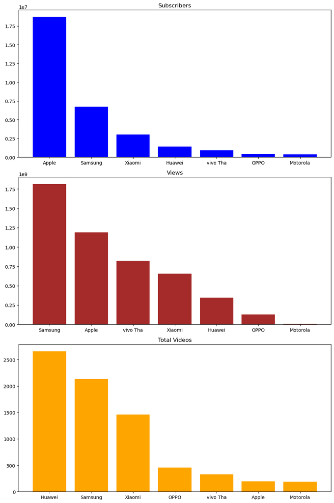

```python
import pandas as pd
import matplotlib.pyplot as plt

# Sort the DataFrame by 'Subscribers' in descending order
combined_phone_brands_channels_df_subscribers_sorted = combined_phone_brands_channels_df.sort_values(by='Subscribers', ascending=False)

# Shorten channel names
combined_phone_brands_channels_df_subscribers_sorted['Channel_name'] = combined_phone_brands_channels_df_subscribers_sorted['Channel_name'].apply(lambda x: x[:8])

# Plotting Subscribers in descending order
fig, axes = plt.subplots(nrows=3, ncols=1, figsize=(10, 15))

axes[0].bar(combined_phone_brands_channels_df_subscribers_sorted['Channel_name'], combined_phone_brands_channels_df_subscribers_sorted['Subscribers'], color='blue')
axes[0].set_title('Subscribers')

# Sort the DataFrame by 'Views' in descending order
combined_phone_brands_channels_df_views_sorted = combined_phone_brands_channels_df.sort_values(by='Views', ascending=False)

# Shorten channel names
combined_phone_brands_channels_df_views_sorted['Channel_name'] = combined_phone_brands_channels_df_views_sorted['Channel_name'].apply(lambda x: x[:8])

# Plotting Views in descending order
axes[1].bar(combined_phone_brands_channels_df_views_sorted['Channel_name'], combined_phone_brands_channels_df_views_sorted['Views'], color='brown')
axes[1].set_title('Views')

# Sort the DataFrame by 'Total_videos' in descending order
combined_phone_brands_channels_df_total_videos_sorted =combined_phone_brands_channels_df.sort_values(by='Total_videos', ascending=False)

# Shorten channel names
combined_phone_brands_channels_df_total_videos_sorted['Channel_name'] = combined_phone_brands_channels_df_total_videos_sorted['Channel_name'].apply(lambda x: x[:8])

# Plotting Total Videos in descending order
axes[2].bar(combined_phone_brands_channels_df_total_videos_sorted['Channel_name'], combined_phone_brands_channels_df_total_videos_sorted['Total_videos'], color='orange')
axes[2].set_title('Total Videos')

# Adjust layout for better visibility
plt.tight_layout()

# Show the plot
plt.show()
```